# Homework2

IE582 Fall 2024 Homework Assignment #2

|  | fixture_id | halftime | current_time | half_start_datetime | match_start_datetime | minute | second | latest_bookmaker_update | suspended | stopped | ... | Throwins - home | Total Crosses - away | Total Crosses - home | Yellowcards - away | Yellowcards - home | Yellowred Cards - away | Yellowred Cards - home | current_state | final_score | result |
| --- | --- | --- | --- | --- | --- | --- | --- | --- | --- | --- | --- | --- | --- | --- | --- | --- | --- | --- | --- | --- | --- |
| 0 | 19172016.0 | 1st-half | 2024-08-09 18:11:36 | 2024-08-09 18:01:37 | 2024-08-09 18:01:37 | 9 | 59 | 2024-08-09 18:11:28 | False | False | ... | 1.0 | 0.0 | 3.0 | 0.0 | 0.0 | 0.0 | 0.0 | X | 2-1 | 1 |
| 1 | 19172016.0 | 1st-half | 2024-08-09 18:27:30 | 2024-08-09 18:01:37 | 2024-08-09 18:01:37 | 25 | 53 | 2024-08-09 18:27:24 | False | False | ... | 11.0 | 1.0 | 12.0 | 0.0 | 0.0 | 0.0 | 0.0 | X | 2-1 | 1 |
| 2 | 19172016.0 | 1st-half | 2024-08-09 18:28:25 | 2024-08-09 18:01:37 | 2024-08-09 18:01:37 | 26 | 48 | 2024-08-09 18:28:20 | False | False | ... | 11.0 | 1.0 | 13.0 | 0.0 | 0.0 | 0.0 | 0.0 | X | 2-1 | 1 |
| 3 | 19172016.0 | 1st-half | 2024-08-09 18:29:32 | 2024-08-09 18:01:37 | 2024-08-09 18:01:37 | 27 | 55 | 2024-08-09 18:29:28 | False | False | ... | 11.0 | 1.0 | 13.0 | 0.0 | 0.0 | 0.0 | 0.0 | X | 2-1 | 1 |
| 4 | 19172016.0 | 1st-half | 2024-08-09 18:30:37 | 2024-08-09 18:01:37 | 2024-08-09 18:01:37 | 29 | 0 | 2024-08-09 18:30:32 | True | False | ... | 11.0 | 1.0 | 14.0 | 0.0 | 0.0 | 0.0 | 0.0 | X | 2-1 | 1 |

5 rows × 106 columns

[output not shown]

[output cut: 51 more lines]

```
 'Successful Passes Percentage - away',
 'Successful Passes Percentage - home',
 'Tackles - away',
 'Tackles - home',
 'Throwins - away',
 'Throwins - home',
 'Total Crosses - away',
 'Total Crosses - home',
 'Yellowcards - away',
 'Yellowcards - home',
 'Yellowred Cards - away',
 'Yellowred Cards - home',
 'current_state',
 'final_score',
 'result']
```

1. Probability Calculation

To make probability calculations easier, of probability function defined at the beginning.

[output not shown]

[output cut: 946 more lines]

[output not shown]

[output not shown]

[output cut: 946 more lines]

[output not shown]

[output not shown]

[output cut: 946 more lines]

[output not shown]

Normalize the calculated probability values:

Plot the probabilities

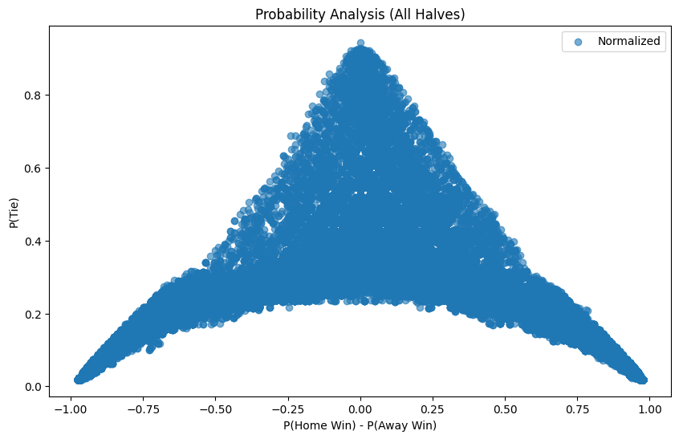

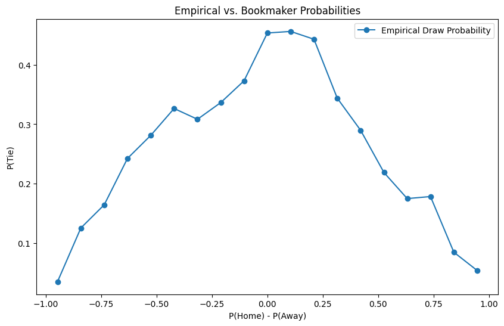

Merge the two probabilities:

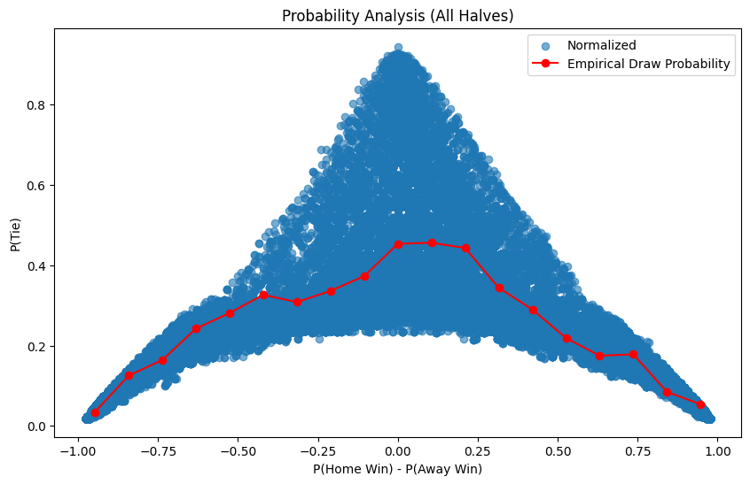

**Conclusion:** There is no visible bias seen in the probabilities.

TASK 2

Condition 1:

|  | 0 |
| --- | --- |
| 0 | False |
| 1 | False |
| 2 | False |
| 3 | False |
| 8 | False |
| ... | ... |
| 63937 | False |
| 63938 | False |
| 63939 | False |
| 63940 | False |
| 63941 | False |

56127 rows × 1 columns

**dtype:** bool

Condition 2:

|  | 0 |
| --- | --- |
| 0 | False |
| 1 | False |
| 2 | False |
| 3 | False |
| 8 | False |
| ... | ... |
| 63937 | False |
| 63938 | False |
| 63939 | False |
| 63940 | False |
| 63941 | False |

56127 rows × 1 columns

**dtype:** bool

The data filtered based on the two conditions defined above. Dimensions of the filtered dataset is given below.

```
(55608, 107)
```

The initial dimensions of the dataset is:

```
(56127, 107)
```

```
Removed matches: 519 out of 56127 total matches.
```

The previously applied probability steps will be applied for the filtered data.

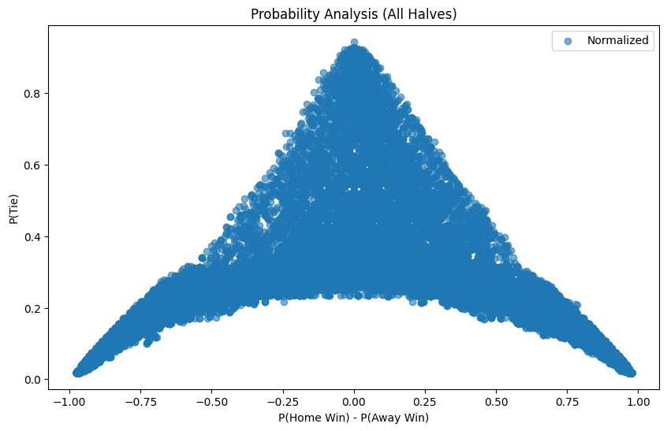

**Conclusion:** There is no significant changes between normalized probabilities and results of task 1. The results visualized with very similar plots.

TASK 3

1. Decision Tree Analysis

|  | P_home_normalized | P_tie_normalized | P_away_normalized |
| --- | --- | --- | --- |
| 0 | 0.763538 | 0.143310 | 0.093152 |
| 1 | 0.773810 | 0.154762 | 0.071429 |
| 2 | 0.773810 | 0.154762 | 0.071429 |
| 3 | 0.773810 | 0.154762 | 0.071429 |
| 4 | 0.781250 | 0.156250 | 0.062500 |

|  | 1 | X | 2 |
| --- | --- | --- | --- |
| 0 | 1.22 | 6.5 | 10.0 |
| 1 | 1.20 | 6.0 | 13.0 |
| 2 | 1.20 | 6.0 | 13.0 |
| 3 | 1.20 | 6.0 | 13.0 |
| 8 | 1.20 | 6.0 | 15.0 |

|  | 1 | X | 2 | result_label |
| --- | --- | --- | --- | --- |
| 0 | 1.22 | 6.5 | 10.0 | 2 |
| 1 | 1.20 | 6.0 | 13.0 | 2 |
| 2 | 1.20 | 6.0 | 13.0 | 2 |
| 3 | 1.20 | 6.0 | 13.0 | 2 |
| 8 | 1.20 | 6.0 | 15.0 | 2 |

Distribution of the labels looks like:

| result_label | count |
| --- | --- |
| 2 | 31482 |
| 0 | 20246 |
| 1 | 4399 |

The real results distributed as:

| result | count |
| --- | --- |
| 1 | 24148 |
| 2 | 16588 |
| X | 15391 |

**dtype:** int64

The difference between probabilities and the actual scores can be shown as:

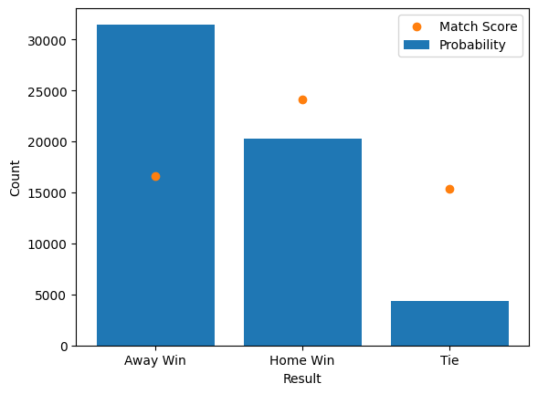

Add new labels into the existing filtered dataframe.

For the tree-training, select features and target. Any variable other than the ones directly related to the results can be a feature. However, for a more detailed analysis we need to group these features.

**Team Performance**

- Shots on and off Target
- Goal Attempts
- Dangerous Attacks

**Actions**

- Corners
- Saves
- Interceptions

**Ball Posessions**

- Ball Possession Percentage
- Successful Passes Percentage

**Penalties**

- Fouls
- Yellow Cards
- Red Cards

Other features such as starting time or fixture ID does not effect the outcome of the game.

Team Performance Metrics

```
DecisionTreeClassifier(max_depth=5, random_state=42)
```

```
Classification Report:
              precision    recall  f1-score   support

           1       0.51      0.84      0.63      4734
           2       0.51      0.43      0.47      3273
           X       0.49      0.10      0.16      3115

    accuracy                           0.51     11122
   macro avg       0.51      0.45      0.42     11122
weighted avg       0.51      0.51      0.45     11122
```

```
Feature Importance:
Shots On Target - away      0.374621
Shots On Target - home      0.316907
Goal Attempts - away        0.110112
Goal Attempts - home        0.061238
Shots Off Target - away     0.052799
Dangerous Attacks - away    0.048752
Dangerous Attacks - home    0.035571
Shots Off Target - home     0.000000
dtype: float64
```

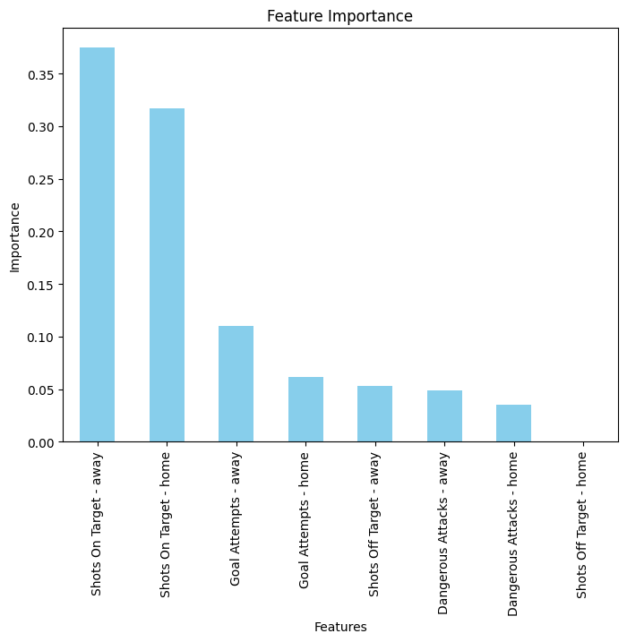

Action Metrics

```
Classification Report:
              precision    recall  f1-score   support

           1       0.45      0.93      0.60      4734
           2       0.52      0.10      0.16      3273
           X       0.46      0.11      0.18      3115

    accuracy                           0.45     11122
   macro avg       0.48      0.38      0.32     11122
weighted avg       0.47      0.45      0.35     11122


Feature Importance:
Interceptions - home    0.262290
Corners - away          0.204837
Saves - home            0.178582
Saves - away            0.170259
Corners - home          0.119554
Interceptions - away    0.064479
dtype: float64
```

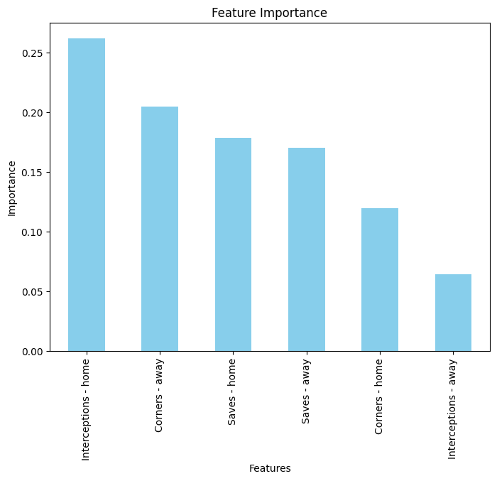

Ball Posession Metrics

```
Classification Report:
              precision    recall  f1-score   support

           1       0.48      0.76      0.59      4734
           2       0.40      0.40      0.40      3273
           X       0.48      0.05      0.09      3115

    accuracy                           0.46     11122
   macro avg       0.45      0.40      0.36     11122
weighted avg       0.46      0.46      0.39     11122


Feature Importance:
Ball Possession % - home               0.353314
Successful Passes Percentage - home    0.321953
Successful Passes Percentage - away    0.252565
Ball Possession % - away               0.072169
dtype: float64
```

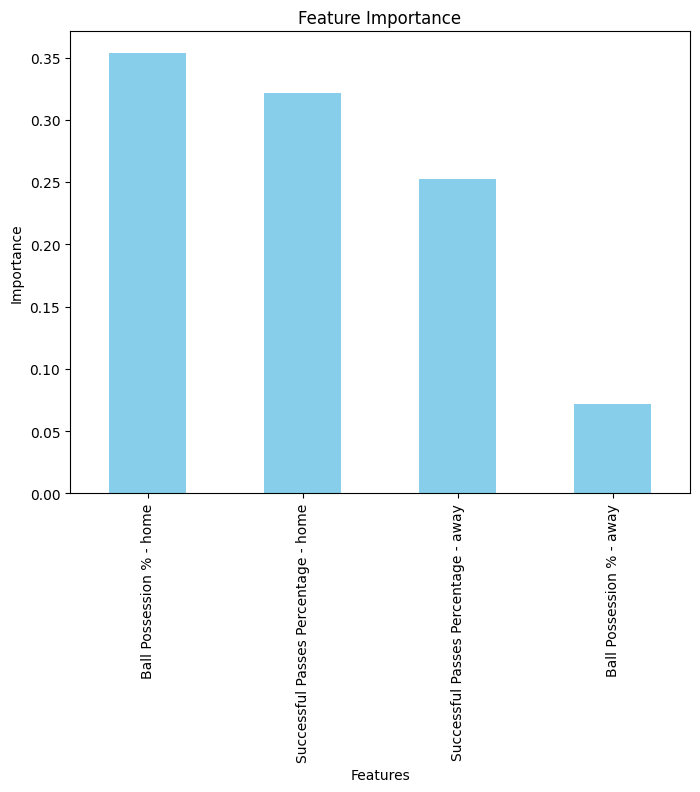

Penalties

```
Classification Report:
              precision    recall  f1-score   support

           1       0.45      0.91      0.60      4734
           2       0.50      0.06      0.11      3273
           X       0.39      0.14      0.20      3115

    accuracy                           0.44     11122
   macro avg       0.45      0.37      0.30     11122
weighted avg       0.45      0.44      0.34     11122


Feature Importance:
Fouls - away              0.225704
Yellowcards - away        0.210286
Yellowcards - home        0.164992
Fouls - home              0.144154
Redcards - home           0.110189
Redcards - away           0.101342
Yellowred Cards - away    0.033230
Yellowred Cards - home    0.010104
dtype: float64
```

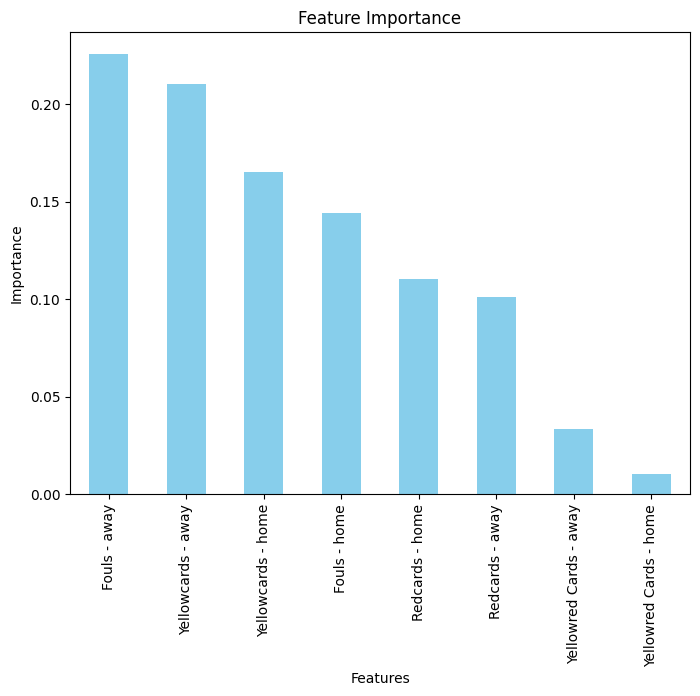

```
Classification Report:
              precision    recall  f1-score   support

           1       0.51      0.81      0.63      4734
           2       0.47      0.52      0.49      3273
           X       0.90      0.01      0.01      3115

    accuracy                           0.50     11122
   macro avg       0.63      0.44      0.38     11122
weighted avg       0.61      0.50      0.42     11122


Feature Importance:
Shots On Target - away                 0.399656
Shots On Target - home                 0.344262
Ball Possession % - away               0.168058
Successful Passes Percentage - home    0.088023
dtype: float64
```

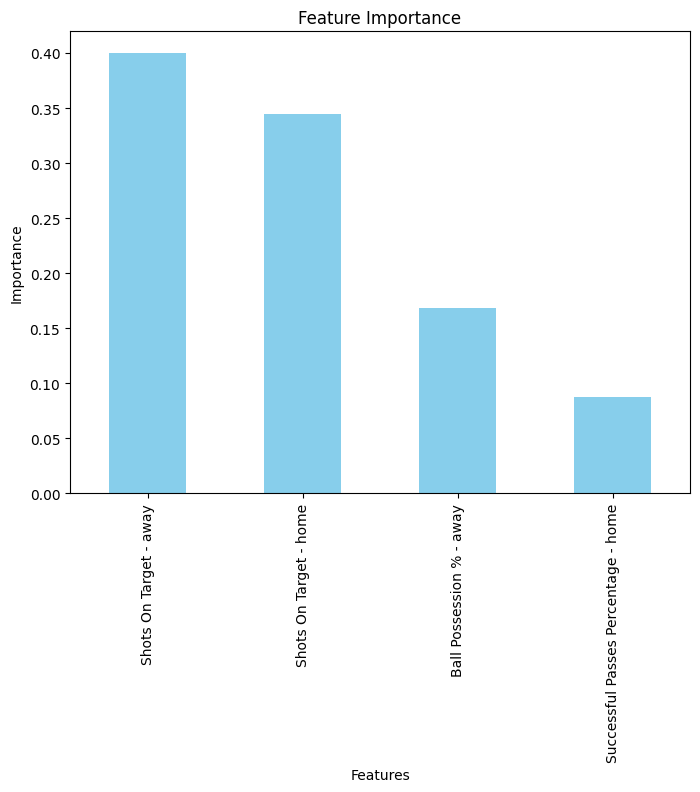

Results of the individual groups did not provide a satisfying analysis. For a more comprehensive study, all groups merged and the decision tree analysis applied to this bigger dataset.

```
Classification Report:
              precision    recall  f1-score   support

           1       0.53      0.77      0.63      4734
           2       0.50      0.51      0.51      3273
           X       0.44      0.14      0.21      3115

    accuracy                           0.52     11122
   macro avg       0.49      0.47      0.45     11122
weighted avg       0.50      0.52      0.48     11122


Feature Importance:
Shots On Target - home                 0.285746
Shots On Target - away                 0.258140
Saves - away                           0.138489
Saves - home                           0.089869
Goal Attempts - away                   0.058227
Ball Possession % - home               0.041363
Fouls - away                           0.029982
Successful Passes Percentage - home    0.026206
Interceptions - home                   0.022385
Ball Possession % - away               0.019450
Shots Off Target - away                0.015164
Yellowcards - away                     0.008683
Dangerous Attacks - home               0.006295
Redcards - away                        0.000000
Yellowred Cards - home                 0.000000
Yellowred Cards - away                 0.000000
Yellowcards - home                     0.000000
Redcards - home                        0.000000
Dangerous Attacks - away               0.000000
Successful Passes Percentage - away    0.000000
Shots Off Target - home                0.000000
Interceptions - away                   0.000000
Corners - home                         0.000000
Corners - away                         0.000000
Goal Attempts - home                   0.000000
Fouls - home                           0.000000
dtype: float64
```

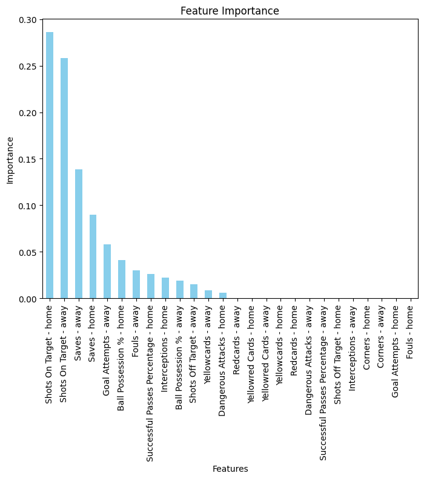

The final features will be:

```
Classification Report:
              precision    recall  f1-score   support

           1       0.53      0.77      0.63      4734
           2       0.50      0.51      0.51      3273
           X       0.44      0.14      0.21      3115

    accuracy                           0.52     11122
   macro avg       0.49      0.47      0.45     11122
weighted avg       0.50      0.52      0.48     11122


Feature Importance:
Shots On Target - home                 0.285655
Shots On Target - away                 0.258173
Saves - away                           0.138507
Saves - home                           0.089881
Goal Attempts - away                   0.058235
Ball Possession % - home               0.041368
Fouls - away                           0.029986
Successful Passes Percentage - home    0.026210
Interceptions - home                   0.022388
Ball Possession % - away               0.019453
Shots Off Target - away                0.015166
Yellowcards - away                     0.008684
Dangerous Attacks - home               0.006296
dtype: float64
```

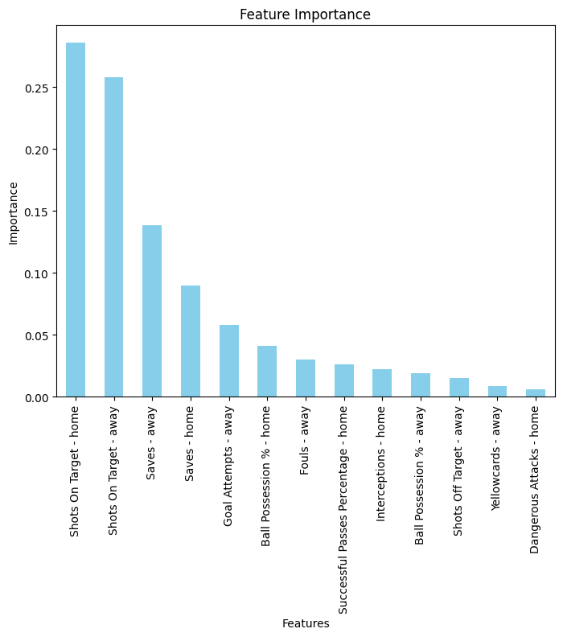

|  | P_home_normalized | P_away_normalized | P_tie_normalized |
| --- | --- | --- | --- |
| 0 | 0.387398 | 0.366697 | 0.245905 |
| 1 | 0.442308 | 0.158832 | 0.398860 |
| 2 | 0.263658 | 0.446577 | 0.289765 |
| 3 | 0.700295 | 0.125664 | 0.174041 |
| 4 | 0.387398 | 0.366697 | 0.245905 |

In the porevious task we calculated the odds as P_away_f, P_home_f and P_tie_f. Later these probabilities normalized. Now, we will place these vakues into a dataframe.

|  | P_home_normalized | P_tie_normalized | P_away_normalized |
| --- | --- | --- | --- |
| 0 | 0.763538 | 0.143310 | 0.093152 |
| 1 | 0.773810 | 0.154762 | 0.071429 |
| 2 | 0.773810 | 0.154762 | 0.071429 |
| 3 | 0.773810 | 0.154762 | 0.071429 |
| 4 | 0.781250 | 0.156250 | 0.062500 |

How much the predicted probabilities deviated from the probabilities given in the data:

|  | P_away_normalized | P_home_normalized | P_tie_normalized |
| --- | --- | --- | --- |
| 0 | 0.273545 | 0.376140 | 0.102595 |
| 1 | 0.087403 | 0.331502 | 0.244098 |
| 2 | 0.375148 | 0.510151 | 0.135003 |
| 3 | 0.054235 | 0.073515 | 0.019279 |
| 4 | 0.304197 | 0.393852 | 0.089655 |